# Assignment 4 (Data Visualization)

## Associations

### Pairplot / heatmap

Make a pairplot and heatmap of all the continuous variables in the data.

*(8 points)*

```python
# dropping release month and release year for the pairplot:
movies_no_release_month_or_year = movies_data.drop(['release_month', 'release_year'], axis=1)
```

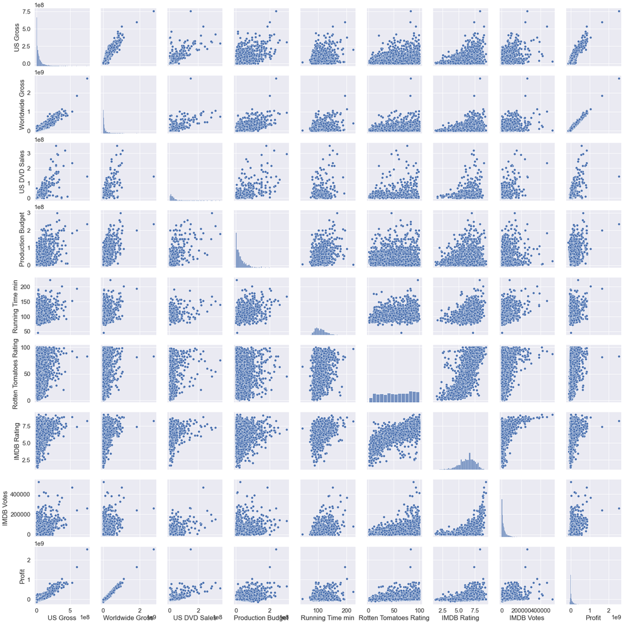

```python
sns.pairplot(movies_no_release_month_or_year)
```

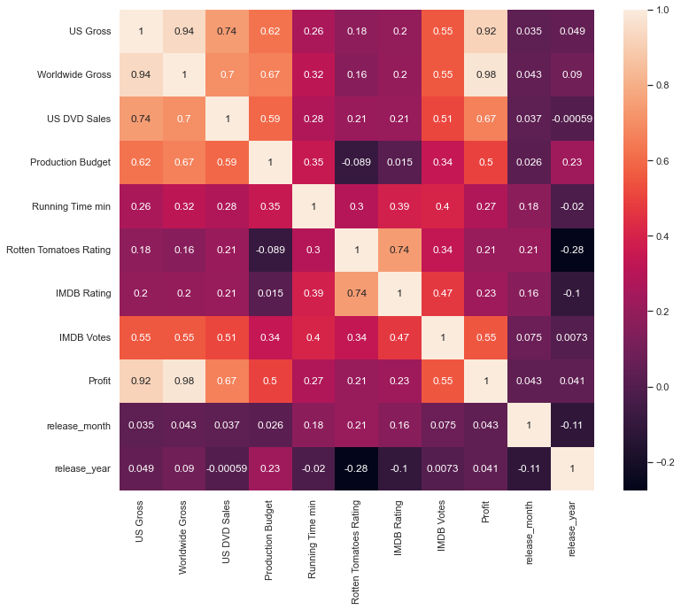

```python
sns.set(rc={'figure.figsize':(12,10)})
sns.heatmap(movies_data.corr(), annot=True)
```

Are there any trends that you can see in the pairplot, but not in the heatmap?

*(2 points)*

Yes. Overall, the pairplot can show deeper intricacies of trends, while heatmaps will give insight on the most general trends between two variables. The pairplot can also show non-linear correlations, while heatmaps will only refelect linear correlations. For example, IMDB votes and IMDB rating appear to be correlated exponentially based on the pairplot, while the heatmap only reflects the linear association between the two.

Based on the plots in 2(a)(i), which variables are associated with profit?

*(2 points)*

Based off the heatmap, US Gross and Worldwide gross are highly positively correlated with profit, while US DVD sales, IMDB votes, and production budget are slightly correlated with profit.

Among the variables listed in 2(a)(iii), select a subset of variables such that none of them are highly associated with each other. The rest of the variables identified in 2(a)(iii) are redundant with regard to association with profit.

*(2 points)*

US DVD sales, IMDB votes, and production budget are all associated, but not highly (all correlation coefficients are less than .7).

### Nested associations

Use the code below to create some new columns.

```python
movies_data['screenplay'] = movies_data.Source.apply(lambda x:'Non-original' if x!='Original Screenplay' else x)
movies_data['rating'] = movies_data['MPAA Rating'].apply(lambda x:'R rated' if x=='R' else 'Not R rated')
movies_data['fiction'] = movies_data['Creative Type'].apply(lambda x:'Contemporary' if x=='Contemporary Fiction' else 'other')
```

Make an appropriate figure to visualize the association of the number of IMDB votes with profit for each genre (use the variable `genre`). Which genre has the highest association between profit and IMDB votes?

*(8 points)*

[figure not shown]

```python
sns.lmplot(
    data=movies_data, x="IMDB Votes", y="Profit",
    col="genre")
```

Action/adventure has the highest association between profit and IMDB votes, with the horror genre as a close second, as shown by the trendlines.

Make an appropriate figure to visualize the association between the number of IMDB votes and profit, for each combination of the fiction type (use the variable `fiction`) and the movie rating (use the variable `rating`).

For which combination of `fiction` and `rating` categories do you observe the highest association between IMDB votes and profit?

*(8 points)*

**Hint:** Use *row* and *col* attributes of the Seaborn [Facetgrid()](https://seaborn.pydata.org/generated/seaborn.FacetGrid.html) object.

[figure not shown]

```python
sns.lmplot(
    data=movies_data, x="IMDB Votes", y="Profit",
    col="fiction", row="rating"
)
```

‘Non R rated’ movies in the ‘other’ category for fiction have the highest correlation between IMDB votes and profit, based on the trendline.

### Profit based on movie director

Consider the directors who have directed more than 10 movies (based on the dataset). Make a horizontal barplot that shows the mean profit of the movies of these directors along with the 95% confidence interval. Sort the bars of the barplot such that the director with the highest mean profit is at the top.

If the dataset `director_with_more_than_10_movies` has only those movies that correspond to directors with more than 10 movies, then the following code will give you the order in which the names of the directors must appear in the barplot:

*(8 points)*

```python
director_count = movies_data['Director'].value_counts()
```

```python
director_count_tenplus = director_count[director_count>10]
names = director_count_tenplus.index.tolist()
```

```python
director_with_more_than_10_movies = movies_data[movies_data['Director'].isin(names)]
director_with_more_than_10_movies[['Director','Profit']].groupby('Director').mean().sort_values(by = 'Profit',
                                            ascending= False).index.to_list()
```

```
['Steven Spielberg',
 'Robert Zemeckis',
 'Tim Burton',
 'Sam Raimi',
 'Ron Howard',
 'Steven Soderbergh',
 'Tony Scott',
 'Ridley Scott',
 'Richard Donner',
 'Joel Schumacher',
 'Martin Scorsese',
 'Barry Levinson',
 'Robert Rodriguez',
 'Clint Eastwood',
 'Oliver Stone',
 'Francis Ford Coppola',
 'Brian De Palma',
 'Renny Harlin',
 'Woody Allen',
 'Spike Lee']
```

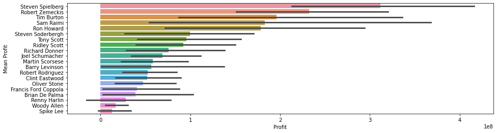

```python
ax = sns.barplot(data=director_with_more_than_10_movies, x='Profit', y ='Director', order =
                director_with_more_than_10_movies[['Director','Profit']].groupby('Director').mean().sort_values(by = 'Profit',
                                            ascending= False).index.to_list())
ax.set(ylabel = 'Mean Profit')
ax.figure.set_figwidth(15)
```

Based on the above plot, which director has the highest mean profitability, and which one has the highest variation in profitability?

*(2 points)*

Steven Spielberg has the highest mean profitability, while Sam Raimi has the highest variation in profitability.

## Distributions

### Distribution of profit based on genre (boxplots)

Make boxplots to visualize the distribution of `profit` based on `genre`. Based on the plot, which genre has the most profitable movies?

*(6 points)*

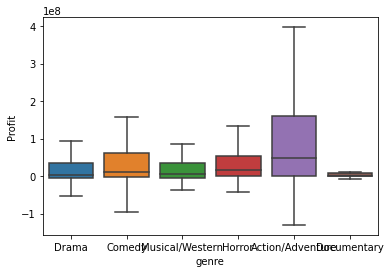

```python
#the outliers are quite extreme for some of the genres, so I'm going to leave them out
sns.boxplot(data = movies_data,x = 'genre', y = 'Profit', showfliers = False)
```

Based on the boxplot, action/adventure is the most profitable genre, as its meadian profit is higher than the other genres, as well as the upper range of its interquartile range.

Which genre has the most variation in profit, and which one has the least?

*(2 points)*

Action/adventure movies have the most variation in profit, while documentaries have the least variation in profit.

### Distribution of profit based on genre (density plots)

Make density plots of `profit` based on `genre`. Adjust the limit on the horizonal axis, so that the plots are clearly visible.

*(6 points)*

```
(-449053241.13259804, 1000000000.0)
```

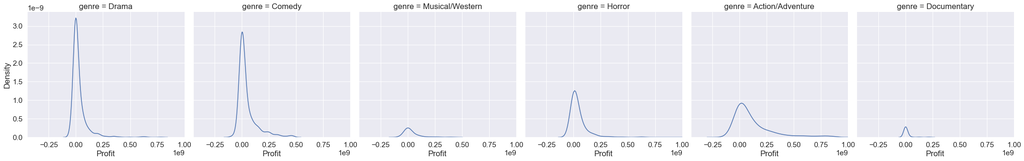

```python
import matplotlib.pyplot as plt
sns.set(font_scale = 1.4)
sns.displot(movies_data, x = 'Profit',kind = 'kde', col = 'genre')
plt.ylim(0, None)
plt.xlim(None, 1e9)
```

What additional insight / trend can you seen in the above plot that you cannot see with the boxplots?

*(2 points)*

## Insights

From all the visualizations above, describe the insights you get about the factors associated with the profitability of a movie.

Also, elaborate on the extent to which these trends can be generalized. For example, comment on whether these trends be generalized to the current time and all the Hollywood movies? If not, is there any time period or type of movie to which these trends can be applicable?

*(4+ 4 points)*

Firstly, there are some variables that seem to be positively correlated with profit: US Gross, Worldwide gross, US DVD sales, IMDB votes, and production budget. US Gross and Worldwide gross can be ignored, as it is obvious that increases in profit would also result in increases in the US and Worldwide Gross variables. The three other variables (US DVD sales, IMDB votes, and production budget) being correlated makes sense. High production budget would most likely result in higher levels of advertisement and an increased amount of high value actors (and other important set members), both of which would increase public engagement with the film. One would also expect that a high profit would also correlate to higher DVD sales. An interesting note: while IMDB votes are positively correlated with profit (high levels engagement with a movie on IMDB probably means that a high number of people watched the movie in the first place), higher IMDB ratings and Rotten Tomato scores are much less positively correlated with profit. In the movie business, it seems that the quanity of interactions is to be desired over the quality of interactions.

If one were to make a movie with the hopes of maximizing profit, I would give them a few pieces of advice: first, if profit is the only goal, then make an action/adventure movie. Based on the boxplots, while action/adventure movies might arguably have the highest risk in that they have the highest potential to lose money (based on the 25th percentile), they have the highest upside in profit, by far. Furthermore, their median profit and interquartile range is significantly above all of the other movies, meaning that one would be more likely to make a high profit through the release of an action adventure movie than any other genre. To lose money in the production of an action/adventure movie would be unlucky, based on this data.

The data visualizations that suggests seasoned directors are profitable makes sense, and would still be applied to Hollywood today. Experience always holds value, and that’s no different in the landscape of moviemaking.

Lastly, while these trends and insights could, and arguably should, influence one’s approach to producing a movie, it’s important to note that correlation does not imply causation. For example, releasing an action/adventure movie in May will not ensure that the movie will be profitable. This is just a trend, and there may be other counfounding variables that go into the success of a movie. So, while these trends can be generalized to the current time, it shouldn’t be done with complete certainty that following these trends will cause the desired outcome. We also don’t know the specifics of how the data was gathered. This dataset seems to be extensive, yet we cannot be completely sure about whether it is an accurate representation of all Hollywood movies, or movies in general.